# OVH servers availability analysis

2023-07-10

## Introduzione

## Introduzione

- L’analisi riguarda il fornitore di servizi cloud chiamato **OVH**
- OVH mette a disposizione server fisici che chi vuole può noleggiare
- I server fisici sono dei computer che il provider dedica interamente ad un cliente, e quindi non possono essere dedicati a più clienti contemporaneamente
- OVH possiede vari datacenters (grandi edifici dove si alloggiano i server) distribuiti in Europa e America del nord
- In ogni datacenter OVH mette a disposizione diversi modelli di server
- Per ogni modello di server e datacenter OVH da informazioni riguardo il tempo stimato di attesa (ETA) per poter noleggiare quel tipo di server

## Domande di partenza

## Che caratteristiche ha il fornitore OVH?

1. Quale è il datacenter migliore, ovvero che abbia i tempi di attesa più bassi?
2. Quale è il modello di server che ha i tempi di attesa più bassi? Quali sono?
3. Le caratteristiche di un server (ram e disco) influenzano la sua disponibilità?
4. C’è correlazione tra le ETA di uno stesso modello di server in datacenters diversi?

## Overview del dataset

## Il dataset

- Raccolto da me personalmente
- È composto da record che contengono 4 informazioni principali
  - La data della misurazione
  - Il datacenter
  - Il modello di server
  - Il tempo stimato di attesa (ETA)
- Inoltre contiene altri dati, come:
  - Le caratteristiche del server: quantità di RAM, tipo e dimensione dei dischi, etc
  - La posizione del datacenter: in quale città e stato si trova

## Il dataset (qualche dato)

- I dati analizzati coprono l’intervallo dal **25/11/2022** al **25/06/2023**, ovvero **7** mesi di dati
- I datacenters sono **7** e si trovano a Beauharnois 🇨🇦, Francoforte 🇩🇪, Gravelinga 🇫🇷, Londra 🇬🇧, Roubaix 🇫🇷, Strasburgo 🇫🇷, Varsavia 🇵🇱
- Le configurazioni server sono **45** e hanno il nome composto dalle loro caratteristiche, ad esempio `32-sr-2x960nv` indica `32` gb di ram, `sr` indica software raid e `2x960nv` indica 2 dischi da 960 GB l’uno di tipo NVMe.
- I tempi di attesa previsti (ETA) sono **7** e sono: 0.25H, 1H, 24H, 72H, 240H, 480H, unavailable

## Collocazione dei datacenters

[figure not shown]

## Analisi

## Prima domanda

### Quale è il datacenter migliore, ovvero che abbia i tempi di attesa più bassi?

[figure not shown]

Notiamo che:

- I DC francesi tendono ad avere un tempo minore di attesa (1 giorno) rispetto agli altri (3 giorni). L’unica eccezione è il DC canadese che è il linea con quelli francesi.
- Conviene quindi scegliere un datacenter francese o canadese, che sono tra di loro simili

## Seconda domanda

### Quale è il modello di server che ha i tempi di attesa più bassi? Quali sono?

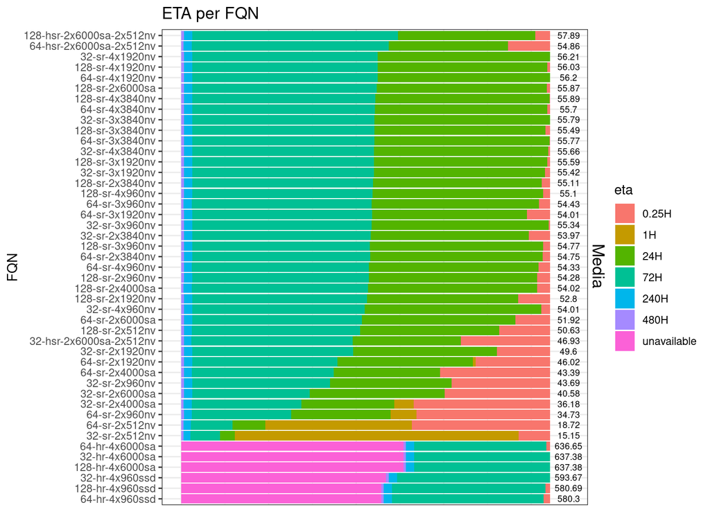

Notiamo che:

- La configurazione con 32 GB di ram, software raid e 2 SSD da 512 Gb l’uno è quella più facilmente disponibile (15 ore in media), seguita dalla stessa configurazione ma con 64 GB di ram
- È interessante notare che la configurazione più spesso disponbile è anche quella selezionata di default sul pannello di acquisto OVH.
- I server che fanno uso di Hardware Raid sono spesso non disponibili (approfondiremo in seguito la questione)
- A parte questi due gruppi, quasi tutti gli altri server hanno disponibilità che oscilla tra 35 e 58 ore

## Terza domanda

### Le caratteristiche di un server (ram e disco) influenzano la sua disponibilità?

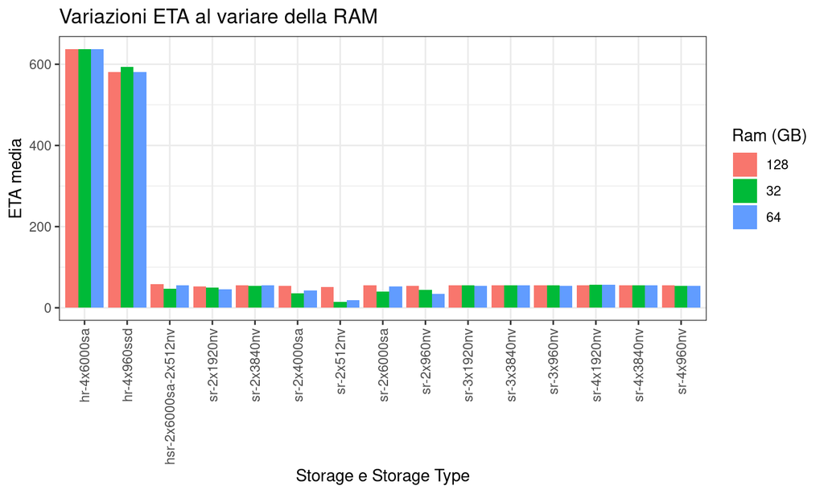

Notiamo che:

- Per il server **sr-2x512nv** la versione con 128 GB di ram ha un tempo di attesa maggiore (50 ore) rispetto alla versione a 32 (15 ore) e 64 GB (18 ore)
- Nel resto dei casi il tempo di attesa non varia significativamente al variare della quantità di RAM all’interno dello stesso modello

## Terza domanda

### Le caratteristiche di un server (ram e disco) influenzano la sua disponibilità?

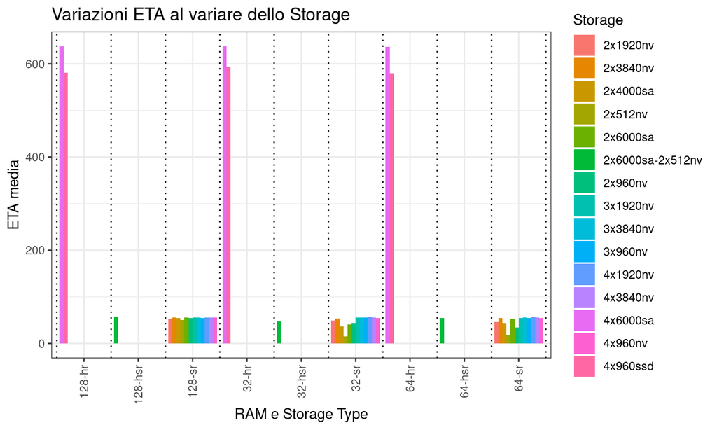

Notiamo che:

- Il tempo di attesa non varia significativamente al variare della quantità di storage all’interno dello stesso modello

## Terza domanda

### Le caratteristiche di un server (ram e disco) influenzano la sua disponibilità?

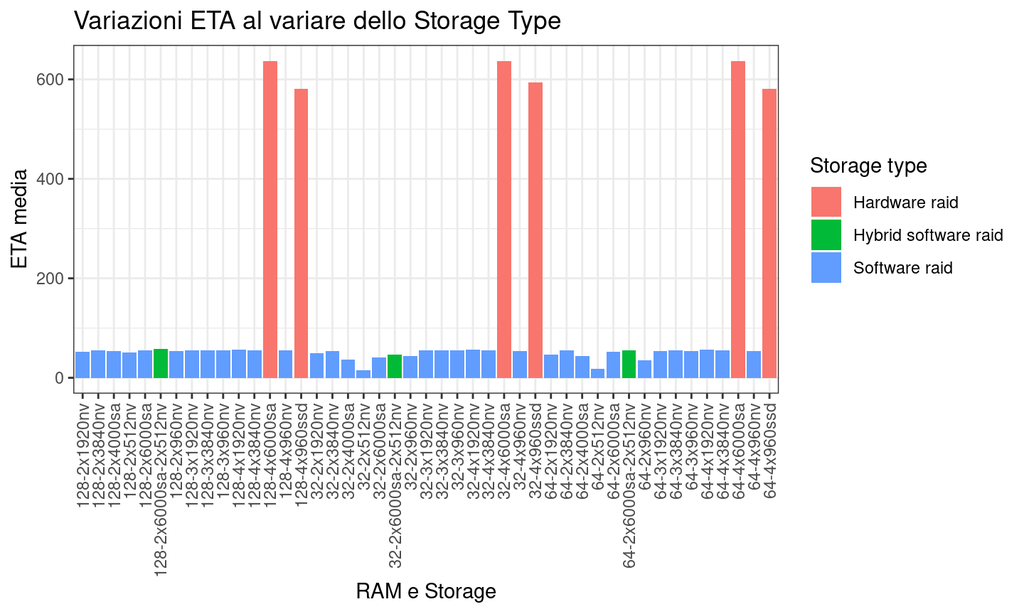

Notiamo che:

- Prima abbiamo notato che i server che fanno uso di Hardware Raid non sono disponibili la maggior parte del tempo e quando lo sono hanno tempi di attesa lunghi (72H)
- Ora vediamo che questo accade indipendentemenete dal tipo di disco usato (4x960 GB SSD o 4x6000 GB HDD sata), quindi è una caratteristica dell’hardware raid.

## Quarta domanda

### C’è correlazione tra le ETA di uno stesso modello di server in datacenters diversi?

[figure not shown]

Notiamo che:

- Che heatmap di correlazione dei server possono essere suddivisi in 4 gruppi
- La prima heatmap in alto a sinstra che rappresenta la maggior parte dei modelli. Notiamo che non c’è particolare correlazione tra i vari datacenter tranne che per Londra 🇬🇧 e Francoforte 🇩🇪.
- Le altre 3 heatmap rappresentano i modelli con hardware raid, che hanno un andamento molto diverso, composto principalmente da due stati. La correlazione è alta. In due casi i datacenter di Francoforte 🇩🇪 e Gravelinga 🇫🇷 hanno un andamento diverso da tutti gli altri.

## Concludendo

**Quale è il modello di server che ha i tempi di attesa più bassi? Quali sono?** Il modello con tempo migliore è `32-sr-2x512nv` con 15 ore di attesa medie

**Le caratteristiche di un server (ram e disco) influenzano la sua disponibilità?** La quantità di RAM e la quantità di disco non influenzano significativamente il tempo di attesa, mentre il tipo di raid si, con l’hardware raid molto meno disponibile degli altri.

**C’è correlazione tra le ETA di uno stesso modello di server in datacenters diversi?** Non c’è particolare correlazione, tranne nel caso dei datacenters Londra 🇬🇧 e Francoforte 🇩🇪. Per alcuni modelli che presentano un andamento molto particolare (composto principalmente da due stati) la correlazione è alta.